# Interfacing your model with R

Florian Hartig

09 March, 2026

Abstract

This tutorial discusses how to interface models written in other programming languages with R, so that they can be fit with BayesianTools

# Interfacing a model with BT - step-by-step guide

## Step 1: Create a runModel(par) function

To enable calibration in BT, it’s essential to run the model with a specified set of parameters. In fact, BT does not see the model as such, but requires a likelihood function with the interface likelihood(par), where par is a vector, but in this function you will probably then run the model with the parameters par, where par could remain a vector or be transformed into some other format, e.g. data.frame, matrix or list.

What happens next depends on how your model is programmed. The following steps are arranged according to speed and convenience. If your model has not been interfaced with R before, you will most likely have to skip to the last option.

### Case 1 - model programmed in R

Typically, no action is required. Ensure that you are able to call your model.

```r
runMyModel(par)
```

Typically this function will directly return the model outputs, so step 2 can be skipped.

### Case 2 - compiled dll, parameters are set via dll interface

```r
dyn.load(model)

runMyModel(par){
  out = # model call here
  # process out
  return(out)
}
```

If you implement this process, you will also usually return the output directly via the `dll` and not write to a file, which means that step 2 can be skipped.

The problem with this approach is that you have to code the interface to your `dll`, which in most programming languages technically means setting your variables as external or something like that, so that they can be accessed from outside. The specifics of how this works will vary depending on the programming language being used.

### Case 3 - model programmed in C / C++, interfaced with RCPP

RCPP provides a highly flexible platform to interface between R and C/C++. RCPP provides a secure and powerful way to connect to R if your model is coded in C/C++ (much more flexible than using the command line or a `dll`).

Nevertheless, code adjustments may be necessary for the interface, and beginners may find it challenging to resolve any technical issues. Attempting to interface an existing C/C++ model without prior experience using RCPP or at least substantial experience with C/C++ is not advisable.

In addition, step 2 can be skipped if you are implementing this, as you will usually return the output directly via the `dll`, rather than writing to a file.

### Case 4 - compiled executable, parameters set via command line (std I/O)

If your model is written in a compiled or interpreted language and accepts parameters via std I/O, wrapping is usually nothing more than writing the system call in an R function. For example

```r
runMyModel(par){

  # Create here a string with what you would write to call the model from the command line
  systemCall <- paste("model.exe", par[1], par[2])

  out = system(systemCall,  intern = TRUE) # intern indicates whether to capture the output of the command as an R character vector

  # write here to convert out in the apprpriate R classes

}
```

Note: If you encounter difficulties with the system command, try system2. If the model provides the output via std.out, you can catch and convert it and skip step 2. If your model writes the output to a file, proceed to step 2.

### Case 5 - compiled model, parameters set via parameter file or in any other method

Many models use parameter files to read parameters. For this case, you want to do something like the following example

```r
runMyModel(par, returnData = NULL){

  writeParameters(par)

  system("Model.exe")

  if(! is.null(returnData)) return(readData(returnData)) # The readData function will be defined later

}

writeParameters(par){

  # e.g.
  # read template parameter fil
  # replace strings in template file
  # write parameter file
}
```

For some problems, it may be useful to create a setup function, as in the example below.

```r
setUpModel <- function(parameterTemplate, site, localConditions){

  # create the runModel, readData functions (see later) here

  return(list(runModel, readData))

}
```

The way you write a parameter function depends on the file format you are using for the parameters. Usually, creating a template parameter file is recommended as a starting point, and then the parameters can be changed as required.

- If your parameter file is in an *.xml format*, check out the xml functions in R.
- If your parameter file is in a *general text format*, the best option may be to create a template parameter file, place a unique string at the locations of the parameters that you want to replace, and then use string replace functions in R, e.g. [grep](https://stat.ethz.ch/R-manual/R-devel/library/base/html/grep.html) to replace this string.

### Case 6 - compiled model, parameters cannot be changed

To achieve one of the previous options, you must change your model code. If the model is in C/C++, the best alternative is to go directly to RCPP.

## Step 2: Read back data

If your model returns the output directly (which is highly preferable, ), you can skip this step.

You can skip this process if your model directly returns the output (which is highly recommended).

If you have a simple model, you might consider using the `runMyModel` function to return the model’s output directly. This is suitable for cases in a) and b) namely, models that are already in R, or receive parameters via the command line.

In contrast, more complex models generate a large number of outputs. However, usually you do not need all of them. Therefore, it is more useful to create one or multiple separate `readData` or `getDate` functions. The only two cases I will consider here are

- via dll / RCPP
- via file ouputs

*Model is a dll* If the model is a `dll` file, it would probably be best to implement appropriate `getData` functions in the source code that can then be called from R. If your model is in C and in a `dll`, interfacing it via RCPP would probably be easier because you can return R dataframes and other data structures directly.

*Model writes file output* If the model generates file output, create a `getData` function that reads the model outputs and returns the data in the desired format, typically the same format you would use to represent your field data.

```r
getData(type = X){

  read.csv(xxx)

  # do some transformation

  # return data in desidered format
}
```

You should now see an example from R that looks like this

```r
par = c(1,2,3,4 ..)

runMyModel(par)

output <- getData(type = DesiredType)

plot(output)
```

## Step 3 (optional) - creating an R package from your code

# Speed optimization and parallelization

Runtime is often a concern when performing sensitivity analyses or calibrations. Ensure that your model has been optimized for maximum speed before parallelization.

## Easy things

- Are you compiling with maximum optimization (e.g. -o3 in cpp)
- If there is a spin-up phase, consider increasing the time step during that phase.
- Consider increasing the time step in general.
- Are you producing unnecessary outputs that could be turned off to reduce hard disk I/O, which is often slow?

## Difficult things

- Make the model directly callable (RCPP or dll) to avoid harddisk I/O
- Is it possible to reduce the initialization time (not only for spin-up, but also for reading the forcings / drivers) by not terminating the model executable after each run, but keeping it “waiting” for a new run?
- Code optimization: did you use a profiler? Read up on code optimization
- Check for unnecessary calculations in your code / introduce compiler flags where appropriate

## Parallelization

One way to speed up the runtime of your model is to run it on multiple cores (CPUs). To do so, you have two choices:

1. Parallelize the model itself
2. Parallelize the model call so that BT can perform multiple model evaluations in parallel.

Which of the two makes more sense depends a lot on your problem. Parallelizing the model itself will be especially interesting for very large models that could not otherwise be calibrated with MCMCs. However, this approach typically requires writing parallel C/C++ code and advanced programming skills, which is why we will not discuss it further here.

The usual advice in parallel computing anyway is to parallelize the outer loops first to minimize the communication overhead, which would suggest starting with parallelizing the model evaluations. This is also much easier to program. Even within that, there are two levels of parallelization possible:

1. Parallelize the call of multiple MCMC / SMC samplers.
2. Parallelize within the MCMC / SMC samplers

Currently, BT only supports parallelization within MCMCs / SMCs, but it easy to also implement between sampler parallelization by hand. Both approaches are describe below.

### Within sampler parallelization

Within-sampler parallelization is particularly useful for algorithms that can use a large number of cores in parallel, such as sensitivity analysis or SMC sampling. For MCMCs, the amount of parallelization that can be used depends on the settings and the algorithm. In general, MCMCs are, as the name implies, Markovian, i.e., they set up a chain of sequential model evaluations, and these calls cannot be fully parallelized. However, a number of MCMCs in the BT package uses MCMC algorithms that can be partly parallelized, in particular the population MCMC algorithms DE/DEzs/DREAM/DREAMzs. In all these cases, BT will automatically use parallelization of the BT setup to indicate that it is implemented.

As an example, suppose we have the following very simple model:

```r
mymodel<-function(x){
  output<-0.2*x+0.1^x
  return(output)
}
```

To start a parallel computation, we must first create a cluster object. Here we start a cluster with 2 CPUs.

```r
library(parallel)
cl <- makeCluster(2)

runParallel<- function(parList){
  parSapply(cl, parList, mymodel)
}

runParallel(c(1,2))
```

You could use this principle to build your own parallelized likelihood. However, something very similar to the previous loop is automated in `BayesianTools`. You can create a parallel model evaluation function directly with the `generateParallelExecuter` function, or alternatively directly in the `createBayesianSetup` function.

```r
library(BayesianTools)
parModel <- generateParallelExecuter(mymodel)
```

If your model is thread-safe, you should be able to run it out of the box. Therefore, I recommend using the hand-coded parallelization only if your model is not thread-safe.

### Running several MCMCs in parallel

In addition to within-chain parallelization, you can also run multiple MCMCs in parallel and later combine them into a single `McmcSamplerList`.

```r
library(BayesianTools)

ll <- generateTestDensityMultiNormal(sigma = "no correlation")
bayesianSetup <- createBayesianSetup(likelihood = ll, lower = rep(-10, 3), upper = rep(10, 3))

settings = list(iterations = 200)

# run the several MCMCs chains either in seperate R sessions, or via R parallel packages
out1 <- runMCMC(bayesianSetup = bayesianSetup, sampler = "DEzs", settings = settings)
```

```
##  Running DEzs-MCMC, chain  1 iteration 201 of 201 . Current logp  -16.84623 -12.12165 -13.12708 . Please wait!
```

```
## runMCMC terminated after 0.114000000000001seconds
```

```r
out2 <- runMCMC(bayesianSetup = bayesianSetup, sampler = "DEzs", settings = settings)
```

```
##  Running DEzs-MCMC, chain  1 iteration 201 of 201 . Current logp  -12.16394 -12.36114 -13.63612 . Please wait!
```

```
## runMCMC terminated after 0.097999999999999seconds
```

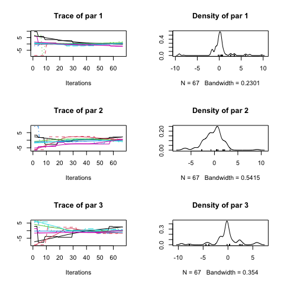

```r
res <- createMcmcSamplerList(list(out1, out2))
plot(res)
```

### Thread safety

Thread safety generally means that you can run multiple instances of your code on your hardware. There are several things that can limit thread safety, such as

- Writing output to a file (multiple threads can write to the same file at the same time)